# Human Activity Recognition Through Machine Learning

Servillano Poserio

January 14, 2016

## Abstract

Human Activity Recognition - HAR - has emerged as a key research area in the last years and is gaining increasing attention by the pervasive computing research community, especially for the development of context-aware systems. There are many potential applications for HAR, like: elderly monitoring, life log systems for monitoring energy expenditure and for supporting weight-loss programs, and digital assistants for weight lifting exercises.

Using devices such as Jawbone Up, Nike FuelBand, and Fitbit it is now possible to collect a large amount of data about personal activity relatively inexpensively. These type of devices are part of the quantified self movement – a group of enthusiasts who take measurements about themselves regularly to improve their health, to find patterns in their behavior, or because they are tech geeks. One thing that people regularly do is quantify how much of a particular activity they do, but they rarely quantify how well they do it. In this project, your goal will be to use data from accelerometers on the belt, forearm, arm, and dumbell of 6 participants. They were asked to perform barbell lifts correctly and incorrectly in 5 different ways.

The goal of this project is to predict the manner in which they did the exercise applying Data Analysis and Machine Learning methodologies.

## Data Source

The data source for this project is courtesy of [Groupware@LES](http://groupware.les.inf.puc-rio.br/har).

## Loading and preprocessing the data

#### 1. Download the training set and the test set. Make sure that the csv files are in the set working directory.

```r
trainSetURL <- "https://d396qusza40orc.cloudfront.net/predmachlearn/pml-training.csv"
testSetURL <- "https://d396qusza40orc.cloudfront.net/predmachlearn/pml-testing.csv"
## set file names
fnTrain <- "pml-training.csv"
fnTest <- "pml-testing.csv"
## Download Training Set
if (!file.exists(fnTrain)) {
  download.file(trainSetURL, destfile=fnTrain)
}
## Download Test Set
if (!file.exists(fnTest)) {
  download.file(testSetURL, destfile=fnTest)
}
```

#### 2. Sanitize and normalize datasets

```r
trainingSet <- read.csv("pml-training.csv",na.strings = c("NA", "", "#DIV/0!"))
trainingSet <- trainingSet[,-c(1:7)]
## Look for missing data and remove them
killNAsTrain <- function(i) {sum(is.na(trainingSet[,i]) * 1) }
normTrainData <- sapply(1:dim(trainingSet)[2],killNAsTrain) == 0
trainingSet <- trainingSet[,normTrainData]
dim(trainingSet)
```

```
## [1] 19622    53
```

```r
## Prep test set
testingSet <- read.csv("pml-testing.csv",na.strings = c("NA", "", "#DIV/0!"))
testingSet <- testingSet[,-c(1:7)]
killNAsTest <- function(i) {sum(is.na(testingSet[,i]) * 1) }
normTestData <- sapply(1:dim(testingSet)[2],killNAsTest) == 0
testingSet <- testingSet[,normTestData]
dim(testingSet)
```

```
## [1] 20 53
```

#### 3. Partition datasets for cross validation

```r
library(caret)
## set seed for reproducibility of this simulation
set.seed(15243)
dpTrain <- createDataPartition(trainingSet$classe, p = 0.7, list = FALSE)
sliceTrain <- trainingSet[dpTrain,]
## Partion training set for cross-validation
sliceCVal <- trainingSet[-dpTrain,]
## kFold Cross validation data. Using 3 folds
kfCV <- trainControl(method = "cv",number = 3)
```

## Build Prediction Model

### Model 1: RPart Classification Algorithm

#### 1. Visualize rpart Tree Model

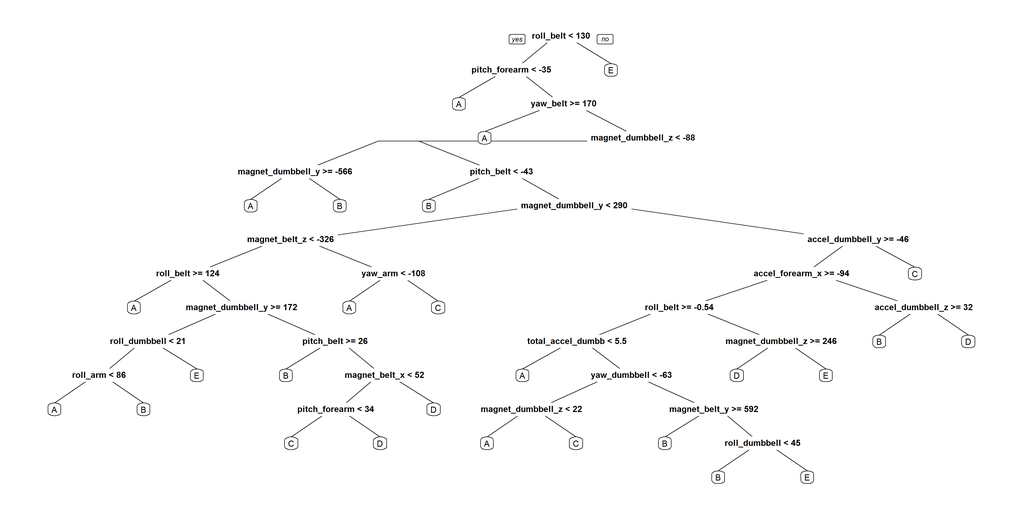

```r
library(rpart)
library(rpart.plot)
treeModel <- rpart(classe ~ ., data=sliceTrain, method="class")
prp(treeModel)
```

#### 2. Train model using rpart classification algorithm with k-fold cross-validation.

```r
rp_fitModel <- train(classe ~ ., data = sliceTrain, method = "rpart" , trControl = kfCV )
print(rp_fitModel)
```

```
## CART
##
## 13737 samples
##    52 predictor
##     5 classes: 'A', 'B', 'C', 'D', 'E'
##
## No pre-processing
## Resampling: Cross-Validated (3 fold)
## Summary of sample sizes: 9159, 9158, 9157
## Resampling results across tuning parameters:
##
##   cp          Accuracy   Kappa       Accuracy SD  Kappa SD
##   0.02441257  0.5620551  0.43577076  0.03214879   0.05283733
##   0.04217272  0.4516368  0.26755333  0.07670431   0.12765008
##   0.11657003  0.3106152  0.04006106  0.04545354   0.06938779
##
## Accuracy was used to select the optimal model using  the largest value.
## The final value used for the model was cp = 0.02441257.
```

```r
tmCVrp <- predict(rp_fitModel, newdata = sliceCVal)
# show confusionMatrix for rpart classification
confusionMatrix(sliceCVal$classe,tmCVrp)
```

```
## Confusion Matrix and Statistics
##
##           Reference
## Prediction    A    B    C    D    E
##          A 1045  199  315  111    4
##          B  159  558  209  213    0
##          C   32  132  829   33    0
##          D   48  139  310  467    0
##          E   18  286  222   81  475
##
## Overall Statistics
##
##                Accuracy : 0.5733
##                  95% CI : (0.5606, 0.586)
##     No Information Rate : 0.3203
##     P-Value [Acc > NIR] : < 2.2e-16
##
##                   Kappa : 0.4652
##  Mcnemar's Test P-Value : < 2.2e-16
##
## Statistics by Class:
##
##                      Class: A Class: B Class: C Class: D Class: E
## Sensitivity            0.8026  0.42466   0.4398  0.51602  0.99165
## Specificity            0.8628  0.87289   0.9507  0.90020  0.88772
## Pos Pred Value         0.6243  0.48990   0.8080  0.48444  0.43900
## Neg Pred Value         0.9390  0.84071   0.7827  0.91099  0.99917
## Prevalence             0.2212  0.22328   0.3203  0.15378  0.08139
## Detection Rate         0.1776  0.09482   0.1409  0.07935  0.08071
## Detection Prevalence   0.2845  0.19354   0.1743  0.16381  0.18386
## Balanced Accuracy      0.8327  0.64878   0.6953  0.70811  0.93968
```

The confusionMatrix indicates that the RPart Classifier model has an accuracy rate of 0.5733. The performance of this model is not as quite as good as expected. We now then try the Random Forest if it’s better.

### Model 2: Random Forest Algorithm

#### 1. Visualize data correlation

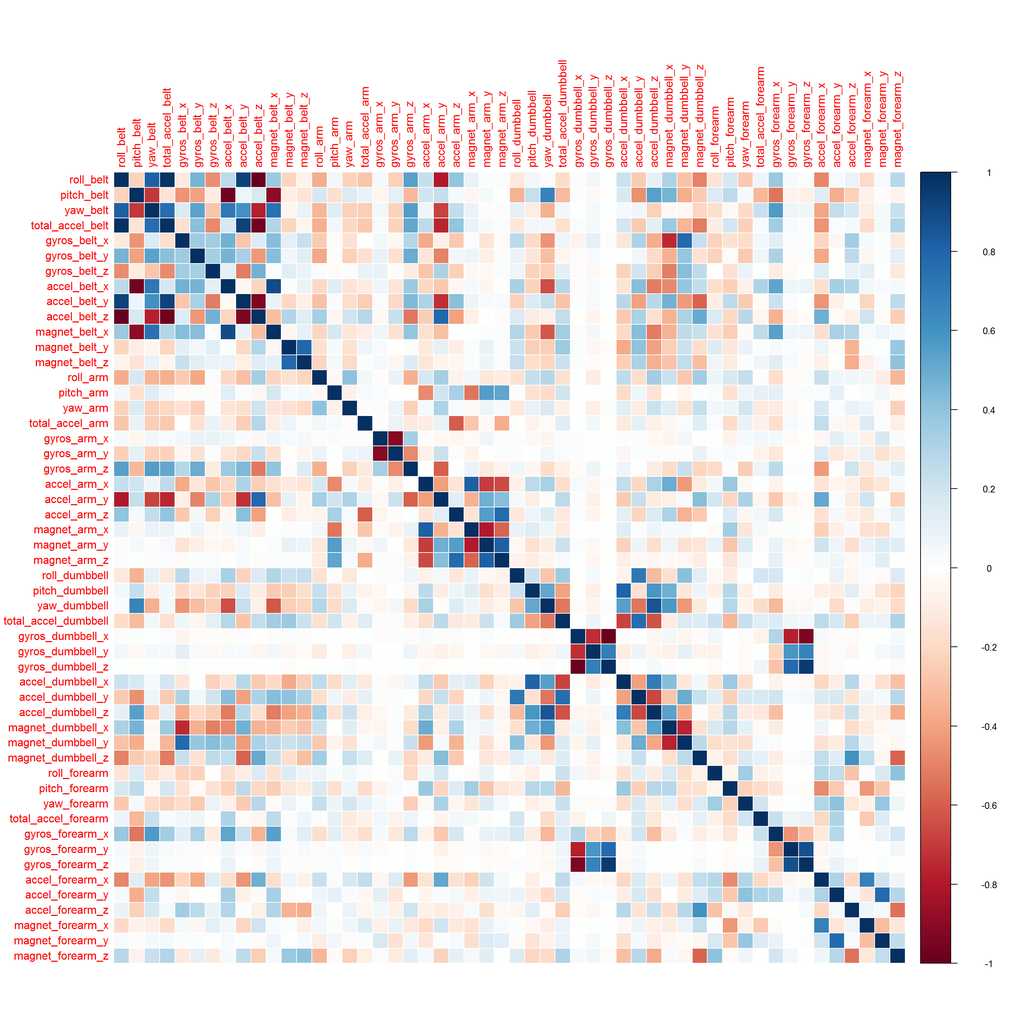

```r
library(corrplot)
rfCorrPlot <- cor(sliceTrain[, -length(names(sliceTrain))])
corrplot(rfCorrPlot, method="color")
```

#### 2. Train model using Random Forest with k-fold cross-validation.

```r
rf_fitModel <- train(classe ~ ., data = sliceTrain, method = "rf" , trControl = kfCV )
#print(rf_fitModel)
```

#### 3. Test/Predict model using cross-validated dataset

```r
tmCVrf <- predict(rf_fitModel, newdata = sliceCVal)
# show confusionMatrix for random forest
confusionMatrix(sliceCVal$classe,tmCVrf)
```

```
## Confusion Matrix and Statistics
##
##           Reference
## Prediction    A    B    C    D    E
##          A 1673    1    0    0    0
##          B    8 1128    1    0    2
##          C    0    6 1013    7    0
##          D    0    1   11  951    1
##          E    0    0    0    1 1081
##
## Overall Statistics
##
##                Accuracy : 0.9934
##                  95% CI : (0.991, 0.9953)
##     No Information Rate : 0.2856
##     P-Value [Acc > NIR] : < 2.2e-16
##
##                   Kappa : 0.9916
##  Mcnemar's Test P-Value : NA
##
## Statistics by Class:
##
##                      Class: A Class: B Class: C Class: D Class: E
## Sensitivity            0.9952   0.9930   0.9883   0.9917   0.9972
## Specificity            0.9998   0.9977   0.9973   0.9974   0.9998
## Pos Pred Value         0.9994   0.9903   0.9873   0.9865   0.9991
## Neg Pred Value         0.9981   0.9983   0.9975   0.9984   0.9994
## Prevalence             0.2856   0.1930   0.1742   0.1630   0.1842
## Detection Rate         0.2843   0.1917   0.1721   0.1616   0.1837
## Detection Prevalence   0.2845   0.1935   0.1743   0.1638   0.1839
## Balanced Accuracy      0.9975   0.9953   0.9928   0.9945   0.9985
```

## Model Selection

Random Forest algorithm by far has the best accuracy by comparison againts RPart Classifier. We applied the generated model to the provided testing data set.

#### Test the model using the testing set.

```r
testRF <- predict(rf_fitModel, newdata = testingSet)
## show results
testRF
```

```
##  [1] B A B A A E D B A A B C B A E E A B B B
## Levels: A B C D E
```